# Introducción a R y RStudio

Bioestadística Fundamental

Andrés Felipe Flórez Rivera

2026-05-09

Universidad Nacional de Colombia — Departamento de Estadística, Sede Bogotá

Este taller es una introducción práctica al lenguaje R y al entorno RStudio, orientada a los temas trabajados en las clases 1 a 8 de Bioestadística Fundamental. No se asume experiencia previa en programación.

## 1. ¿Qué es R y qué es RStudio?

### R

**R** es un lenguaje de programación de código abierto diseñado específicamente para el análisis estadístico y la visualización de datos. Fue creado por Ross Ihaka y Robert Gentleman en la Universidad de Auckland (Nueva Zelanda) a principios de la década de 1990, y hoy es mantenido por el **R Core Team**.

Sus principales características son:

- Es **gratuito** y de código abierto.
- Tiene una comunidad enorme: más de 20 000 paquetes disponibles en [CRAN](https://cran.r-project.org/).
- Es el estándar en estadística académica, ciencias de la salud, biología, agronomía y ciencias sociales.
- Permite producir gráficos de alta calidad listos para publicación.

### RStudio

**RStudio** es un entorno de desarrollo integrado (IDE) que facilita trabajar con R. Proporciona:

- Un editor de código con resaltado de sintaxis.
- Una consola para ejecutar comandos directamente.
- Un panel de visualización de gráficas y resultados.
- Un panel de gestión de archivos, paquetes y variables.

> **Analogía:** si R es el motor, RStudio es el tablero de control del automóvil. Se puede usar R sin RStudio, pero RStudio hace el trabajo mucho más cómodo.

## 2. Instalación en Windows

### Paso 1: instalar R

1. Abra el navegador y vaya a https://cran.r-project.org/bin/windows/base/.
2. Haga clic en el enlace **“Download R X.X.X for Windows”** (la versión más reciente).
3. Ejecute el instalador descargado (`.exe`) y siga el asistente con las opciones predeterminadas.
4. Al finalizar, R estará instalado en su equipo.

### Paso 2: instalar RStudio

1. Vaya a https://posit.co/download/rstudio-desktop/.
2. Haga clic en **“Download RStudio Desktop”** (versión gratuita).
3. Descargue el instalador para Windows (`.exe`) y ejecútelo.
4. Siga el asistente de instalación con las opciones predeterminadas.

### Paso 3: verificar la instalación

Abra RStudio. En la consola (panel inferior izquierdo) escriba:

```r
version
```

Si aparece información sobre la versión de R, la instalación fue exitosa.

## 3. Paquetes en R

Un **paquete** (*package*) es una colección de funciones, datos y documentación que extiende las capacidades base de R. Los paquetes se instalan una sola vez y se cargan en cada sesión de trabajo.

### Instalar un paquete

```r
install.packages("ggplot2")
install.packages("readxl")
install.packages("tidyverse")
```

### Cargar un paquete en la sesión

```r
library(ggplot2)
library(readxl)
library(tidyverse)
```

### Instalar y cargar varios paquetes de una vez

El siguiente patrón instala solo los paquetes que aún no están disponibles y luego los carga todos:

```r
paquetes <- c("ggplot2", "readxl", "tidyverse", "knitr", "kableExtra")

instalados <- rownames(installed.packages())
pendientes <- setdiff(paquetes, instalados)

if (length(pendientes) > 0) {
  install.packages(pendientes)
}

invisible(lapply(paquetes, library, character.only = TRUE))
```

> **Nota:** `install.packages()` requiere conexión a internet. Solo es necesario ejecutarlo una vez por paquete. `library()` debe ejecutarse cada vez que se inicia una sesión de R.

## 4. Carga de datos

R puede leer datos desde varios formatos. A continuación se muestran los más comunes.

### 4.1 Archivos CSV

Un archivo `.csv` (valores separados por comas) es el formato más universal para intercambiar datos tabulares.

```r
# Con R base
datos_csv <- read.csv("ruta/al/archivo.csv")

# Con readr (parte del tidyverse, más rápido y con mejor detección de tipos)
library(readr)
datos_csv <- read_csv("ruta/al/archivo.csv")

# Si el separador es punto y coma (común en archivos exportados en español)
datos_csv <- read_csv2("ruta/al/archivo.csv")
```

Para este taller usaremos datos simulados de cultivos colombianos:

```r
set.seed(42)
n <- 80

datos_cultivo <- data.frame(
  region       = sample(c("Andina", "Caribe", "Pacífico", "Orinoquía"), n, replace = TRUE),
  cultivo      = sample(c("Café", "Maíz", "Arroz", "Papa"), n, replace = TRUE),
  rendimiento  = round(rnorm(n, mean = 3.2, sd = 0.8), 2),  # toneladas/ha
  precipitacion = round(rnorm(n, mean = 1800, sd = 400), 0), # mm/año
  temperatura  = round(rnorm(n, mean = 18, sd = 4), 1),      # °C
  plagas       = sample(c("Sí", "No"), n, replace = TRUE, prob = c(0.3, 0.7))
)

mostrar_tabla(datos_cultivo, n = 8, caption = "Primeras filas del conjunto de datos de cultivos")
```

Primeras filas del conjunto de datos de cultivos

| region | cultivo | rendimiento | precipitacion | temperatura | plagas |
| --- | --- | --- | --- | --- | --- |
| Andina | Papa | 4.41 | 1730 | 15.1 | No |
| Andina | Café | 3.41 | 1371 | 22.0 | No |
| Andina | Maíz | 3.27 | 1865 | 23.0 | No |
| Andina | Café | 3.10 | 1655 | 23.0 | Sí |
| Caribe | Café | 2.24 | 2036 | 12.5 | No |
| Orinoquía | Papa | 3.69 | 2373 | 26.2 | No |
| Caribe | Papa | 3.03 | 1403 | 22.1 | No |
| Caribe | Café | 3.05 | 1982 | 17.9 | No |

### 4.2 Archivos Excel (.xlsx)

```r
library(readxl)

# Leer la primera hoja
datos_excel <- read_excel("ruta/al/archivo.xlsx")

# Especificar hoja y rango
datos_excel <- read_excel("ruta/al/archivo.xlsx", sheet = "Hoja2", range = "A1:F50")
```

### 4.3 Archivos de texto (.txt)

```r
# Separado por tabulaciones
datos_txt <- read.table("ruta/al/archivo.txt", header = TRUE, sep = "\t")

# Separado por espacios
datos_txt <- read.table("ruta/al/archivo.txt", header = TRUE)
```

### 4.4 Explorar el conjunto de datos cargado

Una vez cargados los datos, siempre conviene inspeccionarlos antes de cualquier análisis:

```r
# Dimensiones: filas y columnas
dim(datos_cultivo)
```

```
## [1] 80  6
```

```r
# Nombres de las variables
names(datos_cultivo)
```

```
## [1] "region"        "cultivo"       "rendimiento"   "precipitacion"
## [5] "temperatura"   "plagas"
```

```r
# Estructura y tipos de cada variable
str(datos_cultivo)
```

```
## 'data.frame':    80 obs. of  6 variables:
##  $ region       : chr  "Andina" "Andina" "Andina" "Andina" ...
##  $ cultivo      : chr  "Papa" "Café" "Maíz" "Café" ...
##  $ rendimiento  : num  4.41 3.41 3.27 3.1 2.24 3.69 3.03 3.05 3.95 3.86 ...
##  $ precipitacion: num  1730 1371 1865 1655 2036 ...
##  $ temperatura  : num  15.1 22 23 23 12.5 26.2 22.1 17.9 20.8 14.1 ...
##  $ plagas       : chr  "No" "No" "No" "Sí" ...
```

```r
# Resumen estadístico rápido
summary(datos_cultivo)
```

```
##     region            cultivo           rendimiento    precipitacion
##  Length:80          Length:80          Min.   :1.580   Min.   :1000
##  Class :character   Class :character   1st Qu.:2.700   1st Qu.:1541
##  Mode  :character   Mode  :character   Median :3.100   Median :1778
##                                        Mean   :3.116   Mean   :1788
##                                        3rd Qu.:3.470   3rd Qu.:2000
##                                        Max.   :5.360   Max.   :2624
##   temperatura       plagas
##  Min.   : 7.20   Length:80
##  1st Qu.:15.07   Class :character
##  Median :18.20   Mode  :character
##  Mean   :18.05
##  3rd Qu.:20.93
##  Max.   :27.80
```

## 5. Funciones básicas para análisis de datos

### 5.1 Operaciones con vectores

```r
x <- c(12, 15, 9, 21, 18, 14, 7, 25, 11, 16)

length(x)      # número de elementos
```

```
## [1] 10
```

```r
sum(x)         # suma
```

```
## [1] 148
```

```r
min(x)         # mínimo
```

```
## [1] 7
```

```r
max(x)         # máximo
```

```
## [1] 25
```

```r
range(x)       # rango (mín y máx)
```

```
## [1]  7 25
```

### 5.2 Selección y filtrado de datos

```r
# Filtrar filas donde el cultivo es Café
cafe <- subset(datos_cultivo, cultivo == "Café")
nrow(cafe)
```

```
## [1] 28
```

```r
# Con tidyverse
cafe_tidy <- datos_cultivo |> filter(cultivo == "Café")

# Seleccionar columnas específicas
datos_cultivo |> select(cultivo, rendimiento, region) |> head(5)
```

```
##   cultivo rendimiento region
## 1    Papa        4.41 Andina
## 2    Café        3.41 Andina
## 3    Maíz        3.27 Andina
## 4    Café        3.10 Andina
## 5    Café        2.24 Caribe
```

### 5.3 Crear nuevas variables

```r
datos_cultivo <- datos_cultivo |>
  mutate(
    rendimiento_alto = ifelse(rendimiento > 3.5, "Alto", "Normal"),
    temp_categoria   = cut(temperatura,
                           breaks = c(-Inf, 15, 20, Inf),
                           labels = c("Frío", "Templado", "Cálido"))
  )
```

### 5.4 Tablas de resumen

```r
datos_cultivo |>
  group_by(cultivo) |>
  summarise(
    n              = n(),
    rendimiento_promedio = round(mean(rendimiento), 2),
    rendimiento_sd       = round(sd(rendimiento), 2)
  )
```

```
## # A tibble: 4 × 4
##   cultivo     n rendimiento_promedio rendimiento_sd
##   <chr>   <int>                <dbl>          <dbl>
## 1 Arroz      13                 3.13           0.62
## 2 Café       28                 3.15           0.77
## 3 Maíz       18                 3.16           0.72
## 4 Papa       21                 3.02           0.81
```

## 6. Estadísticas descriptivas: ejemplos prácticos

Esta sección recoge los principales temas vistos en las clases 1 a 8.

### 6.1 Media, mediana y moda (Clase 3)

```r
rendimientos <- datos_cultivo$rendimiento

# Media aritmética
media <- mean(rendimientos)
cat("Media:", round(media, 3), "\n")
```

```
## Media: 3.116
```

```r
# Mediana
mediana <- median(rendimientos)
cat("Mediana:", round(mediana, 3), "\n")
```

```
## Mediana: 3.1
```

```r
# Moda (R base no tiene función directa; la calculamos manualmente)
moda <- function(x) {
  tabla <- table(x)
  as.numeric(names(tabla)[tabla == max(tabla)])
}

cat("Moda del rendimiento:", moda(round(rendimientos, 1)), "\n")
```

```
## Moda del rendimiento: 2.8
```

### 6.2 Medidas de dispersión (Clase 4)

```r
# Rango
rango <- max(rendimientos) - min(rendimientos)
cat("Rango:", round(rango, 3), "\n")
```

```
## Rango: 3.78
```

```r
# Varianza muestral
varianza <- var(rendimientos)
cat("Varianza:", round(varianza, 4), "\n")
```

```
## Varianza: 0.5409
```

```r
# Desviación estándar
de <- sd(rendimientos)
cat("Desviación estándar:", round(de, 4), "\n")
```

```
## Desviación estándar: 0.7355
```

```r
# Coeficiente de variación (%)
cv <- (de / media) * 100
cat("Coeficiente de variación:", round(cv, 2), "%\n")
```

```
## Coeficiente de variación: 23.6 %
```

### 6.3 Cuartiles y percentiles (Clase 4)

```r
# Cuartiles
cuartiles <- quantile(rendimientos, probs = c(0.25, 0.50, 0.75))
cat("Q1:", round(cuartiles[1], 3), "\n")
```

```
## Q1: 2.7
```

```r
cat("Q2 (mediana):", round(cuartiles[2], 3), "\n")
```

```
## Q2 (mediana): 3.1
```

```r
cat("Q3:", round(cuartiles[3], 3), "\n")
```

```
## Q3: 3.47
```

```r
# Rango intercuartílico
riq <- IQR(rendimientos)
cat("Rango intercuartílico (IQR):", round(riq, 3), "\n")
```

```
## Rango intercuartílico (IQR): 0.77
```

```r
# Percentil 90
p90 <- quantile(rendimientos, 0.90)
cat("Percentil 90:", round(p90, 3), "\n")
```

```
## Percentil 90: 4.16
```

### 6.4 Asimetría y curtosis (Clase 4)

```r
# Instalamos e2tools si es necesario
if (!requireNamespace("e1071", quietly = TRUE)) install.packages("e1071")
library(e1071)

asim <- skewness(rendimientos)
curt <- kurtosis(rendimientos)

cat("Asimetría:", round(asim, 4), "\n")
```

```
## Asimetría: 0.438
```

```r
cat("Curtosis (exceso):", round(curt, 4), "\n")
```

```
## Curtosis (exceso): -0.0413
```

```r
if (abs(asim) < 0.5) {
  cat("Distribución aproximadamente simétrica.\n")
} else if (asim > 0) {
  cat("Distribución con asimetría positiva (cola derecha).\n")
} else {
  cat("Distribución con asimetría negativa (cola izquierda).\n")
}
```

```
## Distribución aproximadamente simétrica.
```

### 6.5 Tabla de frecuencias (Clase 2)

```r
# Tabla de frecuencias para una variable cualitativa
tabla_cultivo <- table(datos_cultivo$cultivo)
tabla_df <- data.frame(
  Cultivo             = names(tabla_cultivo),
  Frecuencia_absoluta = as.integer(tabla_cultivo),
  Frecuencia_relativa = round(prop.table(tabla_cultivo), 3),
  Frecuencia_porcentual = round(prop.table(tabla_cultivo) * 100, 1)
)
row.names(tabla_df) <- NULL

mostrar_tabla(tabla_df, n = nrow(tabla_df), caption = "Tabla de frecuencias: tipo de cultivo")
```

Tabla de frecuencias: tipo de cultivo

| Cultivo | Frecuencia_absoluta | Frecuencia_relativa.Var1 | Frecuencia_relativa.Freq | Frecuencia_porcentual.Var1 | Frecuencia_porcentual.Freq |
| --- | --- | --- | --- | --- | --- |
| Arroz | 13 | Arroz | 0.162 | Arroz | 16.2 |
| Café | 28 | Café | 0.350 | Café | 35.0 |
| Maíz | 18 | Maíz | 0.225 | Maíz | 22.5 |
| Papa | 21 | Papa | 0.262 | Papa | 26.2 |

### 6.6 Tabla de contingencia (Clase 5)

```r
tabla_cont <- table(datos_cultivo$cultivo, datos_cultivo$plagas)
colnames(tabla_cont) <- c("Sin plagas", "Con plagas")

mostrar_tabla(
  as.data.frame.matrix(tabla_cont),
  n = 4,
  caption = "Tabla de contingencia: cultivo × presencia de plagas"
)
```

Tabla de contingencia: cultivo × presencia de plagas

|  | Sin plagas | Con plagas |
| --- | --- | --- |
| Arroz | 7 | 6 |
| Café | 16 | 12 |
| Maíz | 13 | 5 |
| Papa | 14 | 7 |

### 6.7 Covarianza y correlación de Pearson (Clase 5)

```r
cov_rp <- cov(datos_cultivo$rendimiento, datos_cultivo$precipitacion)
cor_rp <- cor(datos_cultivo$rendimiento, datos_cultivo$precipitacion)

cat("Covarianza (rendimiento, precipitación):", round(cov_rp, 3), "\n")
```

```
## Covarianza (rendimiento, precipitación): 1.77
```

```r
cat("Correlación de Pearson:", round(cor_rp, 4), "\n")
```

```
## Correlación de Pearson: 0.0066
```

### 6.8 Permutaciones y combinaciones (Clase 6)

En probabilidad usamos conteo combinatorio para calcular espacios muestrales.

```r
# Permutaciones: P(n, k) = n! / (n-k)!
permutacion <- function(n, k) factorial(n) / factorial(n - k)

# Combinaciones: C(n, k) = n! / (k! * (n-k)!)
combinacion <- function(n, k) choose(n, k)

# Ejemplo: en un lote de 10 plantas, ¿de cuántas formas se pueden
# seleccionar 3 para inspección (sin importar el orden)?
cat("Combinaciones C(10,3):", combinacion(10, 3), "\n")
```

```
## Combinaciones C(10,3): 120
```

```r
# ¿Y si el orden importa (primer, segundo y tercer lugar)?
cat("Permutaciones P(10,3):", permutacion(10, 3), "\n")
```

```
## Permutaciones P(10,3): 720
```

```r
# Espacio muestral al lanzar un dado y una moneda
cat("Tamaño del espacio muestral (dado × moneda):", 6 * 2, "\n")
```

```
## Tamaño del espacio muestral (dado × moneda): 12
```

## 7. Visualización de datos

### 7.1 Histograma (Clase 2 y 4)

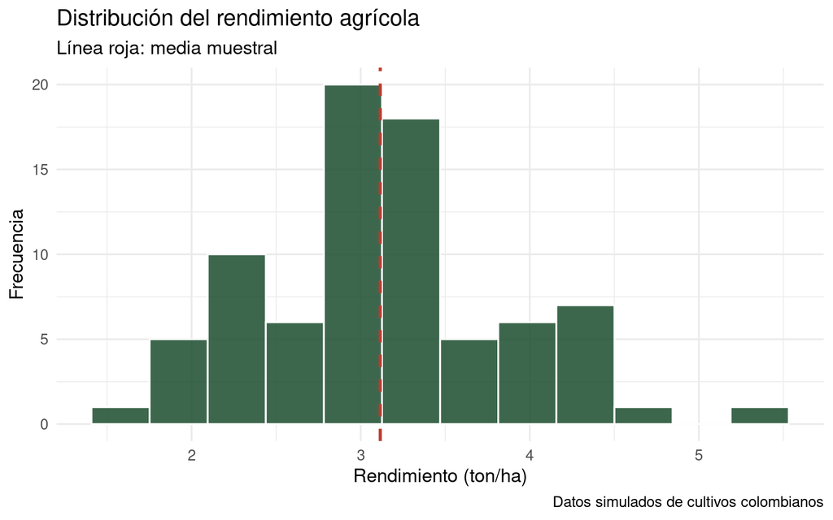

```r
ggplot(datos_cultivo, aes(x = rendimiento)) +
  geom_histogram(bins = 12, fill = "#1b4d2e", color = "white", alpha = 0.85) +
  geom_vline(xintercept = mean(datos_cultivo$rendimiento),
             color = "#c0392b", linetype = "dashed", linewidth = 1) +
  labs(
    title    = "Distribución del rendimiento agrícola",
    subtitle = "Línea roja: media muestral",
    x        = "Rendimiento (ton/ha)",
    y        = "Frecuencia",
    caption  = "Datos simulados de cultivos colombianos"
  ) +
  theme_minimal(base_size = 13)
```

### 7.2 Boxplot (Clase 5)

El boxplot muestra la mediana, los cuartiles Q1 y Q3, y los valores atípicos.

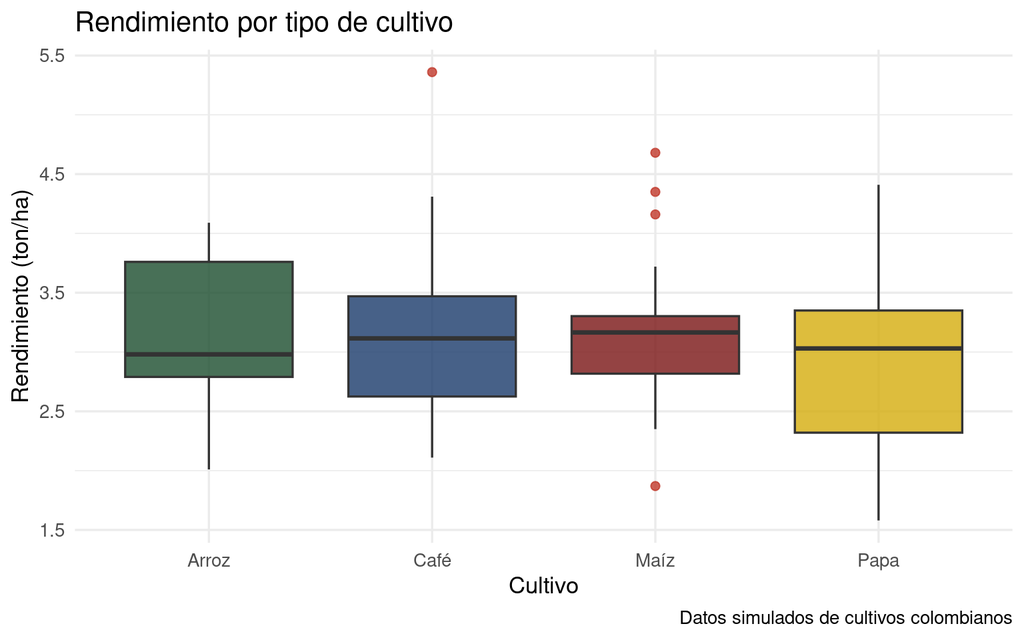

```r
ggplot(datos_cultivo, aes(x = cultivo, y = rendimiento, fill = cultivo)) +
  geom_boxplot(alpha = 0.8, outlier.color = "#c0392b", outlier.size = 2) +
  scale_fill_manual(values = c("#1b4d2e", "#1a3a6b", "#7a1515", "#d4ac0d")) +
  labs(
    title   = "Rendimiento por tipo de cultivo",
    x       = "Cultivo",
    y       = "Rendimiento (ton/ha)",
    caption = "Datos simulados de cultivos colombianos"
  ) +
  theme_minimal(base_size = 13) +
  theme(legend.position = "none")
```

### 7.3 Gráfico de barras (Clase 2)

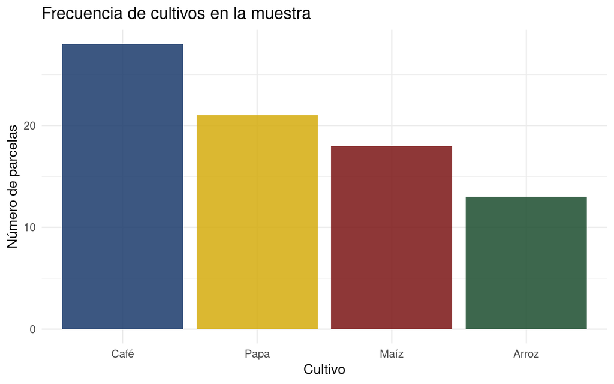

```r
datos_cultivo |>
  count(cultivo) |>
  ggplot(aes(x = reorder(cultivo, -n), y = n, fill = cultivo)) +
  geom_col(alpha = 0.85) +
  scale_fill_manual(values = c("#1b4d2e", "#1a3a6b", "#7a1515", "#d4ac0d")) +
  labs(
    title = "Frecuencia de cultivos en la muestra",
    x     = "Cultivo",
    y     = "Número de parcelas"
  ) +
  theme_minimal(base_size = 13) +
  theme(legend.position = "none")
```

### 7.4 Diagrama de dispersión (Clase 5)

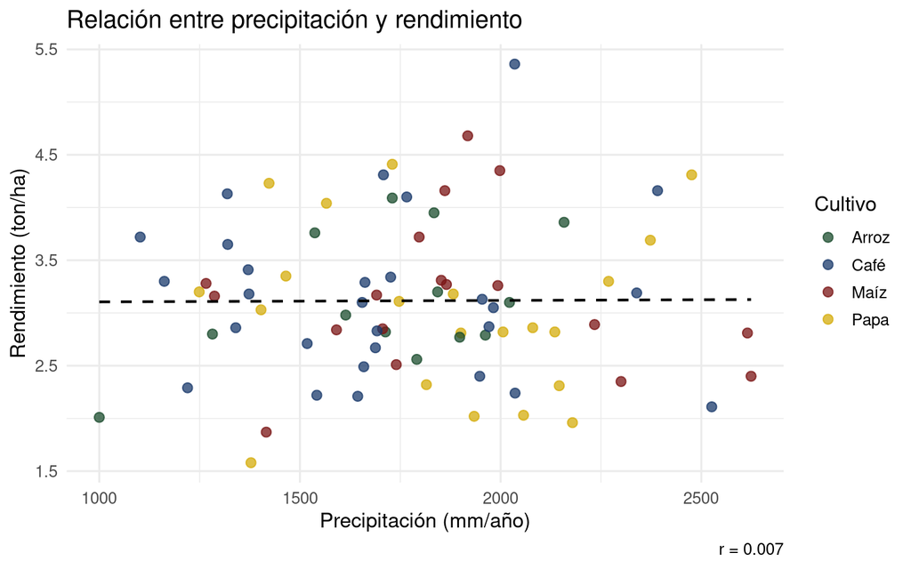

```r
ggplot(datos_cultivo, aes(x = precipitacion, y = rendimiento, color = cultivo)) +
  geom_point(size = 2.5, alpha = 0.75) +
  geom_smooth(method = "lm", se = FALSE, color = "black", linewidth = 0.8,
              linetype = "dashed") +
  scale_color_manual(values = c("#1b4d2e", "#1a3a6b", "#7a1515", "#d4ac0d")) +
  labs(
    title   = "Relación entre precipitación y rendimiento",
    x       = "Precipitación (mm/año)",
    y       = "Rendimiento (ton/ha)",
    color   = "Cultivo",
    caption = paste0("r = ", round(cor(datos_cultivo$precipitacion,
                                       datos_cultivo$rendimiento), 3))
  ) +
  theme_minimal(base_size = 13)
```

### 7.5 Gráfico de barras agrupadas (Clase 5)

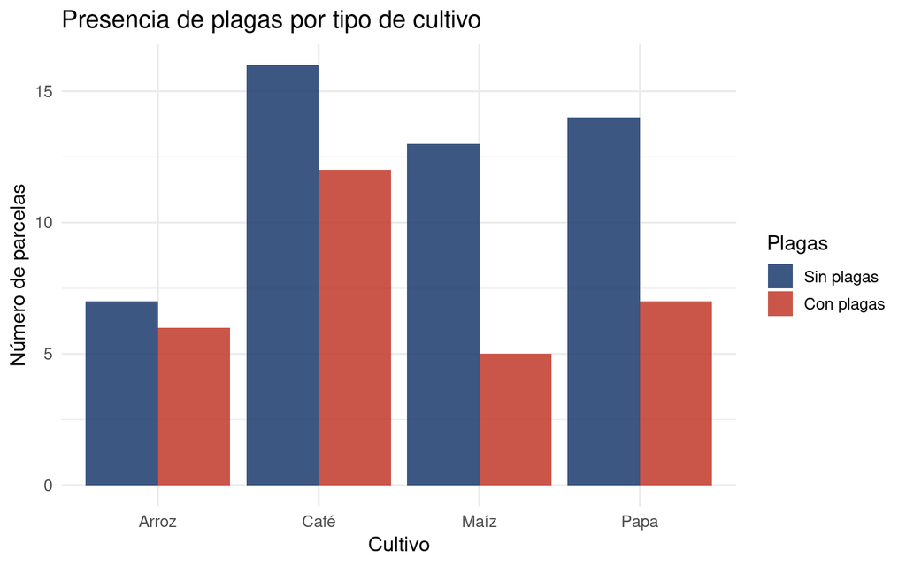

```r
datos_cultivo |>
  count(cultivo, plagas) |>
  ggplot(aes(x = cultivo, y = n, fill = plagas)) +
  geom_col(position = "dodge", alpha = 0.85) +
  scale_fill_manual(values = c("#1a3a6b", "#c0392b"),
                    labels = c("Sin plagas", "Con plagas")) +
  labs(
    title = "Presencia de plagas por tipo de cultivo",
    x     = "Cultivo",
    y     = "Número de parcelas",
    fill  = "Plagas"
  ) +
  theme_minimal(base_size = 13)
```

### 7.6 Resumen visual completo por región

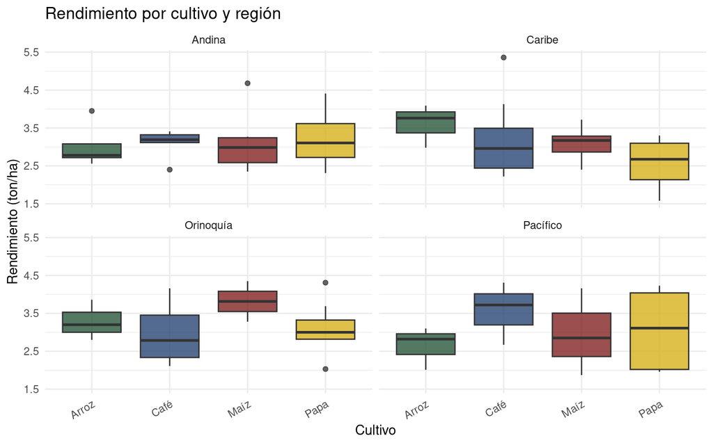

```r
ggplot(datos_cultivo, aes(x = cultivo, y = rendimiento, fill = cultivo)) +
  geom_boxplot(alpha = 0.75, outlier.size = 1.5) +
  scale_fill_manual(values = c("#1b4d2e", "#1a3a6b", "#7a1515", "#d4ac0d")) +
  facet_wrap(~region) +
  labs(
    title = "Rendimiento por cultivo y región",
    x     = "Cultivo",
    y     = "Rendimiento (ton/ha)"
  ) +
  theme_minimal(base_size = 11) +
  theme(legend.position = "none",
        axis.text.x = element_text(angle = 30, hjust = 1))
```

## 8. Probabilidad: ejemplos en R (Clases 6, 7 y 8)

### 8.1 Probabilidad clásica

```r
# Espacio muestral: lanzar dos dados
omega <- expand.grid(dado1 = 1:6, dado2 = 1:6)
nrow(omega)  # 36 resultados igualmente probables
```

```
## [1] 36
```

```r
# Evento A: la suma es mayor que 8
A <- subset(omega, dado1 + dado2 > 8)
prob_A <- nrow(A) / nrow(omega)
cat("P(suma > 8):", round(prob_A, 4), "\n")
```

```
## P(suma > 8): 0.2778
```

```r
# Evento B: el primer dado muestra un número par
B <- subset(omega, dado1 %% 2 == 0)
prob_B <- nrow(B) / nrow(omega)
cat("P(dado1 par):", round(prob_B, 4), "\n")
```

```
## P(dado1 par): 0.5
```

### 8.2 Probabilidad condicional (Clase 7)

```r
# P(A | B): suma mayor que 8 dado que el primer dado es par
AB <- subset(omega, dado1 %% 2 == 0 & dado1 + dado2 > 8)

prob_A_dado_B <- nrow(AB) / nrow(B)
cat("P(suma > 8 | dado1 par):", round(prob_A_dado_B, 4), "\n")
```

```
## P(suma > 8 | dado1 par): 0.3333
```

```r
# Verificación con la definición: P(A ∩ B) / P(B)
cat("Verificación:", round((nrow(AB) / nrow(omega)) / prob_B, 4), "\n")
```

```
## Verificación: 0.3333
```

### 8.3 Teorema de Bayes (Clase 8)

Ejemplo de prueba diagnóstica para resistencia a la roya en café:

- Prevalencia de resistencia: P(R) = 0.35
- Sensibilidad de la prueba: P(+|R) = 0.90
- Especificidad: P(−|R^c) = 0.85

```r
p_R    <- 0.35   # prevalencia
sens   <- 0.90   # P(+ | R)
espec  <- 0.85   # P(- | R^c)

p_Rc   <- 1 - p_R
p_pos_Rc <- 1 - espec  # P(+ | R^c) = tasa de falsos positivos

# Probabilidad total de resultado positivo
p_pos  <- sens * p_R + p_pos_Rc * p_Rc

# Teorema de Bayes: P(R | +)
p_R_dado_pos <- (sens * p_R) / p_pos

cat("P(resultado positivo):", round(p_pos, 4), "\n")
```

```
## P(resultado positivo): 0.4125
```

```r
cat("P(resistente | prueba positiva):", round(p_R_dado_pos, 4), "\n")
```

```
## P(resistente | prueba positiva): 0.7636
```

```r
cat("Valor predictivo positivo (VPP):", round(p_R_dado_pos * 100, 1), "%\n")
```

```
## Valor predictivo positivo (VPP): 76.4 %
```

## 9. Ejercicio propuesto

Con el conjunto de datos `datos_cultivo` construido en este taller:

1. Calcule la media, mediana y desviación estándar del rendimiento para cada tipo de cultivo. ¿Cuál cultivo presenta mayor variabilidad?
2. Construya una tabla de frecuencias de la variable `temp_categoria`. ¿Qué proporción de parcelas se encuentra en la categoría “Cálido”?
3. Elabore un histograma de la variable `precipitacion`. Describa la forma de la distribución (simétrica, asimétrica positiva, asimétrica negativa).
4. Calcule la correlación de Pearson entre `temperatura` y `rendimiento`. Interprete el resultado.
5. En un lote con 40% de probabilidad de presencia de plagas (evento P):
   - Si se sabe que la temperatura es cálida y P(plaga | cálido) = 0.55, ¿cuál es la probabilidad de que una parcela cálida tenga plagas?
   - Usando el Teorema de Bayes, si P(cálido | plaga) = 0.60 y P(cálido) = 0.45, calcule P(plaga | cálido) y compare con el valor anterior.